[figure not shown]

**Income and Right to Work in the United States**

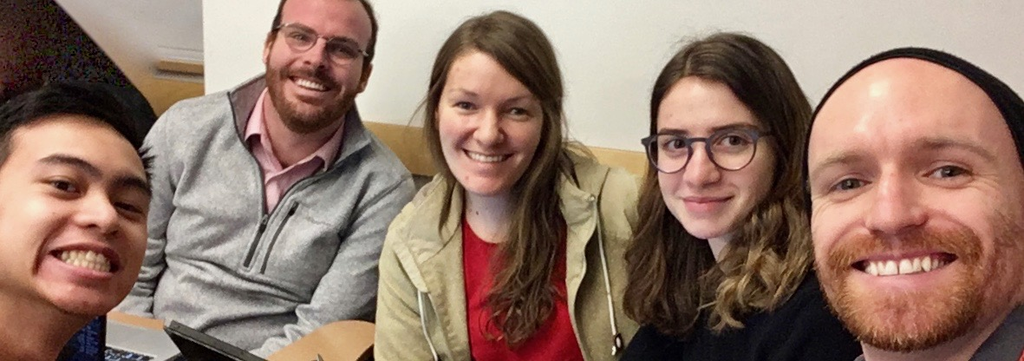

Group: Evan L, Evan M, Darcy, Ana, and Caz

**Contents:**

1. Introduction
2. Analysis
3. Findings

**Introduction and Data Overview**

**The Right to Work (RTW) Policy**

The Right to Work (RTW) refers to state laws that prohibit unions from compelling individuals to join, or pay union dues as condition for employment.. In addition, Right to Work laws often prohibit contracts that mandate only hiring a unionized workforce.

Although Right to Work laws may seem beneficial to some, critics argue that they are inherently “anti-union.” Due to the existence of federal laws that prevent mandatory union membership, and some argue that Right to Work laws harm unions’ bargaining strength, subsequently lowering salaries and benefits for vulnerable workers.

**Data**

We are drawing our data from a subsample of the American Community Survey (ACS) data from the year 2016. The ACS is a survey conducted annually by the U.S. Census Bureau, gathering long-form information previously collected in the Decennial (conducted in years ending 0) Census.

Using IPUMS, we specified a variety of variables that we wanted to include in our dataset including Wage Income, Gender, and Age. Then we created a separate dataset manually (using the information available online) that included a binary variable where 1 indicated the state had Right to Work policies in place, and 0 indicated there were no Right to Work policies in place.

Using Python, we cleaned up the datasets by renaming columns, changing data types as necessary, and removing missing values and values that didn’t fit. We then combined the two datasets. Using the new, combined dataset, we limited the evaluation to all people in the working age range, designated as 25-65. Finally, that dataset was exported from Python as a CSV to be uploaded to R for modeling and visualization purposes. You can find the pre-processed Python document in our Repo.

**Purpose of Analysis**

Our analysis aims to contribute to this discussion of Right to Work. We aim to consider the relationship between Right to Work laws and outcomes for workforce in terms of income. We specifically looked at the wage income as it is directly connected with the job renumeration versus total income that can include other non-work related sources of income as well.

These are our hypothesis:

- $H_{0}$ = There is no significant difference in the means of income wages in states with RTW and without RTW.
- $H_{1}$ = There is a significant difference in the means of income wage in states with RTW and without RTW.

Go back to the table of contents

**Analysis**

**RTW effects on Income**

We see from this model that RTW status results in a 7724.29 decrease in income. However, the R-squared for this model is low and so additional modeling that includes other independent variables might improve the ability of the model to explain the relationship between Right to Work and income.

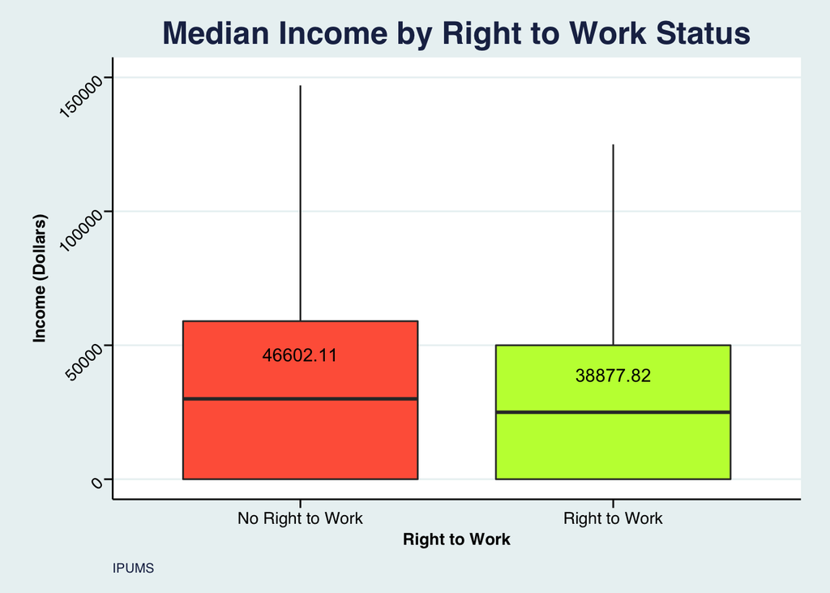

```
##
## Call:
## lm(formula = incwage ~ Right_to_Work, data = dataset)
##
## Residuals:
##    Min     1Q Median     3Q    Max
## -46602 -38878 -13878  15122 697122
##
## Coefficients:
##                Estimate Std. Error t value Pr(>|t|)
## (Intercept)    46602.11      68.28  682.50   <2e-16 ***
## Right_to_Work1 -7724.29      97.08  -79.57   <2e-16 ***
## ---
## Signif. codes:  0 '***' 0.001 '**' 0.01 '*' 0.05 '.' 0.1 ' ' 1
##
## Residual standard error: 61530 on 1607065 degrees of freedom
## Multiple R-squared:  0.003924,   Adjusted R-squared:  0.003923
## F-statistic:  6331 on 1 and 1607065 DF,  p-value: < 2.2e-16
```

Our adjusted R squared is fairly small.

```
## [1] 0.003923441
```

**RTW effects on males and females**

The results below shows that the presence of RTW laws effect both male and female income earnings. For Females in states with no RTW laws, the average income is **35929**, while females in states with RTW laws earn **29113**. For Males in states with no RTW laws, the average income is **57619**, while males in states with RTW earn **49021**.

Furthermore, on average, all else equal, being an RTW State is associated with a decrease of USD 7691.56 in the wage income. Also, on average, all else equal, being a male is associated with an increase of USD 20809.02 in annual wage income.

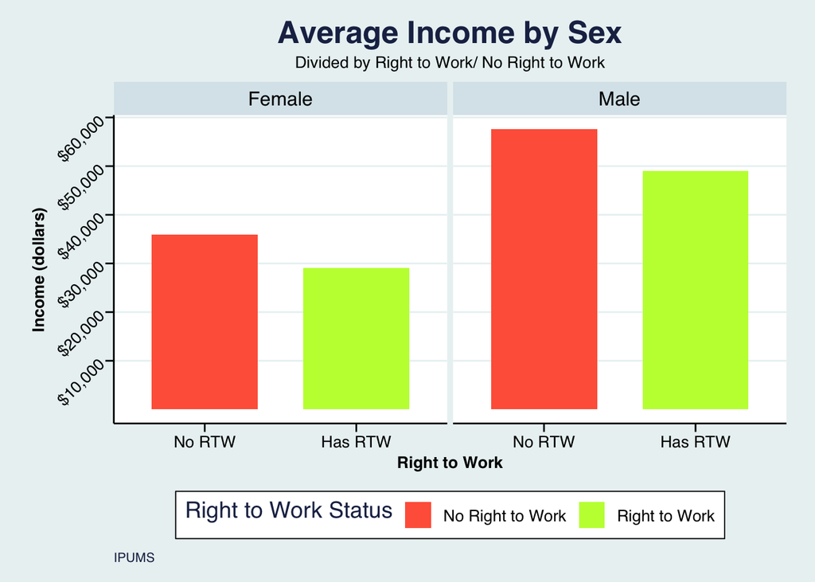

```
## # A tibble: 4 x 3
## # Groups:   sex [2]
##   sex    Right_to_Work   mean
##   <chr>  <fct>          <dbl>
## 1 Female 0             35929.
## 2 Female 1             29113.
## 3 Male   0             57619.
## 4 Male   1             49021.
```

```
##
## Call:
## lm(formula = incwage ~ Right_to_Work + sex, data = dataset)
##
## Residuals:
##    Min     1Q Median     3Q    Max
## -57171 -33171 -13362  15520 707329
##
## Coefficients:
##                Estimate Std. Error t value Pr(>|t|)
## (Intercept)    36362.47      82.14  442.71   <2e-16 ***
## Right_to_Work1 -7691.56      95.68  -80.39   <2e-16 ***
## sexMale        20809.02      95.69  217.46   <2e-16 ***
## ---
## Signif. codes:  0 '***' 0.001 '**' 0.01 '*' 0.05 '.' 0.1 ' ' 1
##
## Residual standard error: 60640 on 1607064 degrees of freedom
## Multiple R-squared:  0.0324, Adjusted R-squared:  0.0324
## F-statistic: 2.69e+04 on 2 and 1607064 DF,  p-value: < 2.2e-16
```

Our Adjusted R Squared for this model is still small but higher than the previous one.

```
## [1] 0.03239612
```

This t-test shows if there is a significant difference in the mean values of income between Males and Females. With a P-value of 2.2e-16, we can safely reject the null hypothesis that there is no difference in the mean values of income between Males and Females.

```
##
##  Welch Two Sample t-test
##
## data:  incwage by sex
## t = -215.56, df = 1331800, p-value < 2.2e-16
## alternative hypothesis: true difference in means is not equal to 0
## 95 percent confidence interval:
##  -21010.44 -20631.81
## sample estimates:
## mean in group Female   mean in group Male
##             32551.29             53372.42
```

**Let’s consider additional independent variable - age**

On average, all else equal, being an RTW State is associated with a decrease of USD 7736.112 in the wage income. Also, on average, all else equal, one more year in age is associated with an increase of approximately USD 71 in annual wages. Our adjusted R-squared for this regression is small.

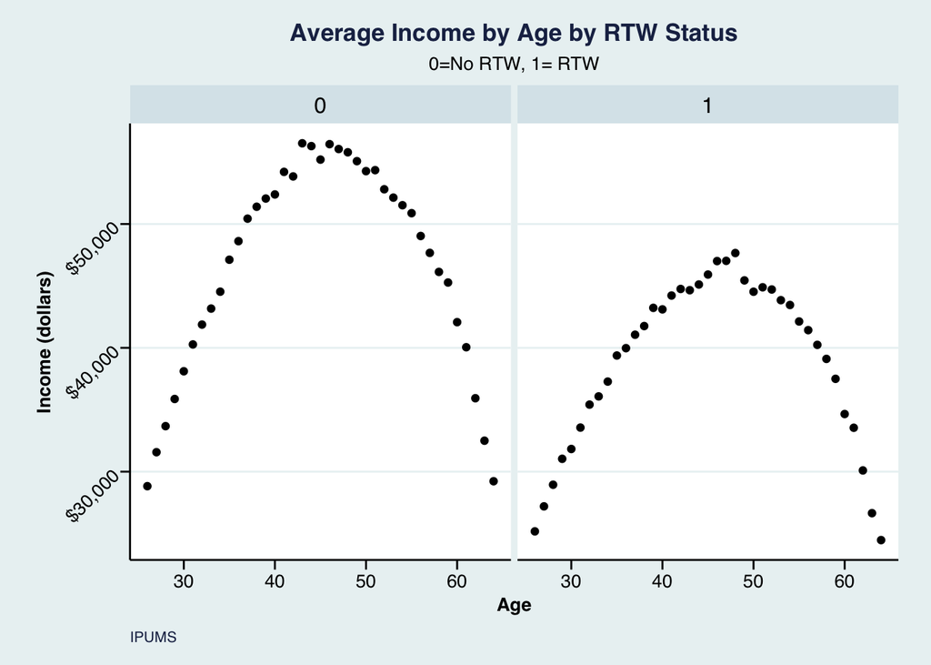

```
##
## Call:
## lm(formula = incwage ~ Right_to_Work + age, data = dataset)
##
## Residuals:
##    Min     1Q Median     3Q    Max
## -47896 -38596 -13763  14886 698328
##
## Coefficients:
##                 Estimate Std. Error t value Pr(>|t|)
## (Intercept)    43346.178    207.205  209.19   <2e-16 ***
## Right_to_Work1 -7736.112     97.072  -79.69   <2e-16 ***
## age               71.094      4.272   16.64   <2e-16 ***
## ---
## Signif. codes:  0 '***' 0.001 '**' 0.01 '*' 0.05 '.' 0.1 ' ' 1
##
## Residual standard error: 61520 on 1607064 degrees of freedom
## Multiple R-squared:  0.004096,   Adjusted R-squared:  0.004094
## F-statistic:  3305 on 2 and 1607064 DF,  p-value: < 2.2e-16
```

Our Adjusted R squared is really small which means the model is not strong.

```
## [1] 0.004094474
```

**T test**

The p-value for the interaction between sex*Right_to_Work is <2e-16 (significant), which indicates that the relationships between Right to Work and income length depends on gender - if the individual is male or female.

```
##
##  Welch Two Sample t-test
##
## data:  incwage by Right_to_Work
## t = 79.719, df = 1567500, p-value < 2.2e-16
## alternative hypothesis: true difference in means is not equal to 0
## 95 percent confidence interval:
##  7534.384 7914.203
## sample estimates:
## mean in group 0 mean in group 1
##        46602.11        38877.82
```

```
##                        Df    Sum Sq   Mean Sq  F value Pr(>F)
## sex                     1 1.741e+14 1.741e+14 47348.11 <2e-16 ***
## Right_to_Work           1 2.377e+13 2.377e+13  6462.57 <2e-16 ***
## sex:Right_to_Work       1 3.190e+11 3.190e+11    86.74 <2e-16 ***
## Residuals         1607063 5.910e+15 3.677e+09
## ---
## Signif. codes:  0 '***' 0.001 '**' 0.01 '*' 0.05 '.' 0.1 ' ' 1
```

**A new regression model**

Given the fact that our previous regression models were weak, we decided to run more comprehensive model on our outcome variable- income wage.

```
##
## Call:
## lm(formula = incwage ~ Right_to_Work + age + sex, data = dataset)
##
## Residuals:
##    Min     1Q Median     3Q    Max
## -58770 -32890 -12974  15387 707516
##
## Coefficients:
##                 Estimate Std. Error t value Pr(>|t|)
## (Intercept)    32368.210    210.341  153.88   <2e-16 ***
## Right_to_Work1 -7705.943     95.670  -80.55   <2e-16 ***
## age               86.851      4.211   20.63   <2e-16 ***
## sexMale        20842.934     95.691  217.81   <2e-16 ***
## ---
## Signif. codes:  0 '***' 0.001 '**' 0.01 '*' 0.05 '.' 0.1 ' ' 1
##
## Residual standard error: 60640 on 1607063 degrees of freedom
## Multiple R-squared:  0.03265,    Adjusted R-squared:  0.03265
## F-statistic: 1.808e+04 on 3 and 1607063 DF,  p-value: < 2.2e-16
```

Still no significant improvement over the previous models.

```
## [1] 0.03265162
```

Explanatory variables are not highly correlated.

```
## Right_to_Work           age           sex
##         FALSE         FALSE         FALSE
```

**Comparing Regression Models**

Our models are clearly stastically inaccurate. We can see that the estimates are inflated. We assume our independent variables are not sufficient or the type of the model (linear) for this analysis is flawed. Confidence intervals seem to be really small, hence the dots instead of a horizontal line representing the range.

[figure not shown]

Go back to top of the page

Go back to the table of contents

[Go to the Project Repo](https://github.com/EvanLih/PUBPOL599_Right_To_Work)